# Problem_1

# Problem 1: Predicting healthcare charges, in USD, using a patient’s age and BMI as features

```r
library(readr)
library(ggplot2)
library(tidyverse)
library(rpart) # this is what we use to make the decision tree
library(rpart.plot)
library(dplyr)
```

```r
df <- read_csv("./insurance_charges.csv")
head(df)
```

| age | bmi | charges | f_bmi | cardiovascular_care_cost |
| --- | --- | --- | --- | --- |
| 19 | 3.901049 | 16884.924 | 0.5911814 | 1875.837 |
| 18 | 5.194726 | 1725.552 | 0.7155626 | 2466.233 |
| 28 | 5.003189 | 4449.462 | 0.6992469 | 2472.825 |
| 33 | 3.027632 | 21984.471 | 0.4811030 | 1656.104 |
| 32 | 4.092107 | 3866.855 | 0.6119470 | 1933.298 |
| 31 | 3.510852 | 3756.622 | 0.5454126 | 1548.085 |

```r
summary(df)
```

```
      age             bmi            charges          f_bmi        cardiovascular_care_cost
 Min.   :18.00   Min.   : 2.179   Min.   : 1122   Min.   :0.3382   Min.   : 827.1
 1st Qu.:27.00   1st Qu.: 3.607   1st Qu.: 4740   1st Qu.:0.5572   1st Qu.:1784.1
 Median :39.00   Median : 4.407   Median : 9382   Median :0.6442   Median :2204.5
 Mean   :39.21   Mean   : 4.672   Mean   :13270   Mean   :0.6497   Mean   :2338.0
 3rd Qu.:51.00   3rd Qu.: 5.434   3rd Qu.:16640   3rd Qu.:0.7351   3rd Qu.:2720.7
 Max.   :64.00   Max.   :13.359   Max.   :63770   Max.   :1.1258   Max.   :6621.8
```

Let us start with really basic exploratory data analysis to gain some understanding on our data.

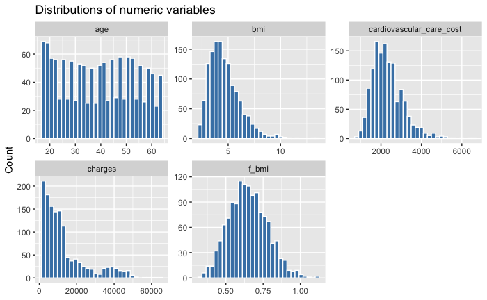

```r
# Look at the distributions of numeric columns
df |>
  select(where(is.numeric)) |>
  pivot_longer(everything(), names_to = "var", values_to = "val") |>
  ggplot(aes(val)) +
  geom_histogram(bins = 30, fill = "steelblue", color = "white") +
  facet_wrap(~ var, scales = "free") +
  labs(title = "Distributions of numeric variables", x = NULL, y = "Count")
```

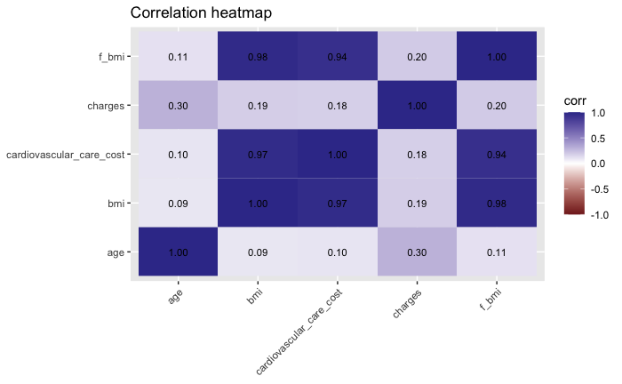

```r
# Correlation matrix heatmap
corr_mat <- cor(df |> select(where(is.numeric)), use = "pairwise.complete.obs")

corr_mat |>
  as.data.frame() |>
  tibble::rownames_to_column("var1") |>
  pivot_longer(-var1, names_to = "var2", values_to = "corr") |>
  ggplot(aes(var1, var2, fill = corr)) +
  geom_tile() +
  geom_text(aes(label = sprintf("%.2f", corr)), size = 3) +
  scale_fill_gradient2(limits = c(-1, 1)) +
  labs(title = "Correlation heatmap", x = NULL, y = NULL) +
  theme(axis.text.x = element_text(angle = 45, hjust = 1))
```

## a)

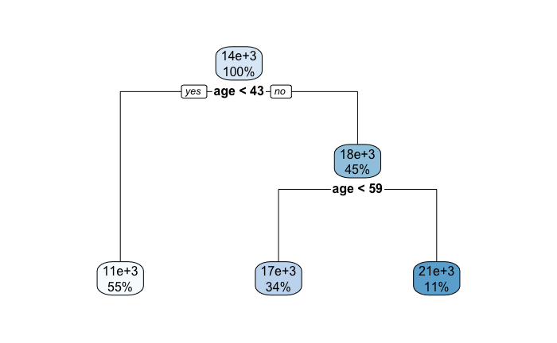

```r
# Decision tree predicting charges based on bmi and age.
model1 <- rpart(charges ~ age, bmi, data = df)

# Plots the decision tree
rpart.plot(model1)
```

```r
# Returns a summary of the model
summary(model1)
```

```
Call:
rpart(formula = charges ~ age, data = df, weights = bmi)
  n= 1338

          CP nsplit rel error    xerror       xstd
1 0.06646995      0 1.0000000 1.0014713 0.02247329
2 0.01095788      1 0.9335300 0.9357764 0.02141321
3 0.01000000      2 0.9225722 0.9416296 0.02152954

Variable importance
age
100

Node number 1: 1338 observations,    complexity param=0.06646995
  mean=13987.49, MSE=1.686433e+08
  left son=2 (755 obs) right son=3 (583 obs)
  Primary splits:
      age < 42.5 to the left,  improve=0.06646995, (0 missing)

Node number 2: 755 observations
  mean=10961.62, MSE=1.548827e+08

Node number 3: 583 observations,    complexity param=0.01095788
  mean=17692.11, MSE=1.605566e+08
  left son=6 (444 obs) right son=7 (139 obs)
  Primary splits:
      age < 58.5 to the left,  improve=0.02560143, (0 missing)

Node number 6: 444 observations
  mean=16548.01, MSE=1.542857e+08

Node number 7: 139 observations
  mean=21284.86, MSE=1.632305e+08
```

```r
# R-squared ( from training data)
pred <- predict(model1, df)
rss <- sum((df$charges - pred)^2)                # residual sum of squares
tss <- sum((df$charges - mean(df$charges))^2)   # total sum of squares
rsq <- 1 - rss/tss

cat("The Training R-squared is:", round(rsq, 3), "\n")
```

```
The Training R-squared is: 0.088
```

The R-squared obtained is equal to 8.8%, which is low and shows that the model has not learnt deeply the relationship we want to model.

## b)

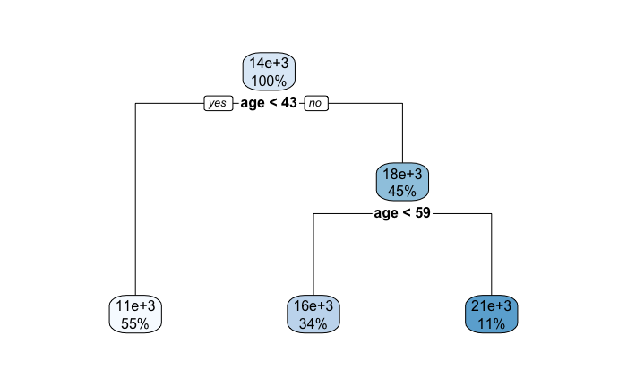

```r
# Decision tree predicting charges based on f_bmi and age.
model1 <- rpart(charges ~ age, f_bmi, data = df)

# Plots the decision tree
rpart.plot(model1)
```

```r
# Returns a summary of the model
summary(model1)
```

```
Call:
rpart(formula = charges ~ age, data = df, weights = f_bmi)
  n= 1338

          CP nsplit rel error    xerror       xstd
1 0.07042646      0 1.0000000 1.0018437 0.06155177
2 0.01190059      1 0.9295735 0.9327989 0.05859585
3 0.01000000      2 0.9176729 0.9350443 0.05919070

Variable importance
age
100

Node number 1: 1338 observations,    complexity param=0.07042646
  mean=13747.75, MSE=1.606751e+08
  left son=2 (755 obs) right son=3 (583 obs)
  Primary splits:
      age < 42.5 to the left,  improve=0.07042646, (0 missing)

Node number 2: 755 observations
  mean=10733.14, MSE=1.463161e+08

Node number 3: 583 observations,    complexity param=0.01190059
  mean=17501.4, MSE=1.531487e+08
  left son=6 (444 obs) right son=7 (139 obs)
  Primary splits:
      age < 58.5 to the left,  improve=0.02803182, (0 missing)

Node number 6: 444 observations
  mean=16332.09, MSE=1.456117e+08

Node number 7: 139 observations
  mean=21172.83, MSE=1.590411e+08
```

```r
# R-squared ( from training data)
pred <- predict(model1, df)
rss <- sum((df$charges - pred)^2)                # residual sum of squares
tss <- sum((df$charges - mean(df$charges))^2)   # total sum of squares
rsq <- 1 - rss/tss

cat("The Training R-squared is:", round(rsq, 3), "\n")
```

```
The Training R-squared is: 0.09
```

We get a R-squared value fairly small (9%), which testifies that the model has not well learnt the training data and that perhaps, we need a more complex model.

## c)

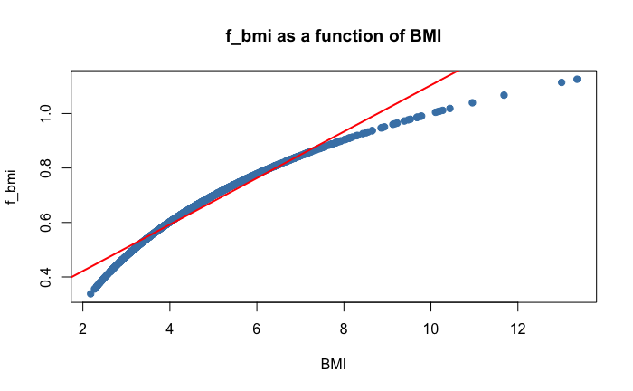

```r
# Plot f_bmi as a function of bmi
plot(df$bmi, df$f_bmi,
     xlab = "BMI",
     ylab = "f_bmi",
     main = "f_bmi as a function of BMI",
     pch = 19, col = "steelblue")
abline(lm(f_bmi ~ bmi, data = df), col = "red", lwd = 2)
```

## e)

Firstly, we should define clearly which dependent variables we would like to keep. We will not use bmi since it is highly correlated to f_bmi, as shown above. We will keep age, and add charges, since it is not a value we aim to predict anymore.

```r
# Grid of cp values
cps <- c(0, 0.02, 0.04, 0.06, 0.08, 0.1)

# Fit tree at a given cp and compute training metrics
fit_one <- function(cp) {

  fit <- rpart(cardiovascular_care_cost ~ age + f_bmi + charges,
               data = df,
               control = rpart.control(cp = cp))  # keep other defaults

  y <- df$cardiovascular_care_cost
  pred <- predict(fit, df)
  rss <- sum((y - pred)^2); tss <- sum((y - mean(y))^2)
  r2  <- 1 - rss/tss
  rmse <- sqrt(mean((y - pred)^2))

  leaves <- sum(fit$frame$var == "<leaf>")

  depth <- max(rpart:::tree.depth(as.numeric(row.names(fit$frame))))

  tibble(cp = cp, R2 = r2, RMSE = rmse, Leaves = leaves, Depth = depth, model = list(fit))
}

# Run fits
res <- bind_rows(lapply(cps, fit_one))

# Show summary table (metrics only)
res %>% select(cp, R2, RMSE, Leaves, Depth)
```

| cp | R2 | RMSE | Leaves | Depth |
| --- | --- | --- | --- | --- |
| 0.00 | 0.9517420 | 169.1137 | 111 | 12 |
| 0.02 | 0.8852636 | 260.7624 | 6 | 3 |
| 0.04 | 0.8257149 | 321.3841 | 4 | 2 |
| 0.06 | 0.8257149 | 321.3841 | 4 | 2 |
| 0.08 | 0.8257149 | 321.3841 | 4 | 2 |
| 0.10 | 0.7344426 | 396.7104 | 3 | 2 |

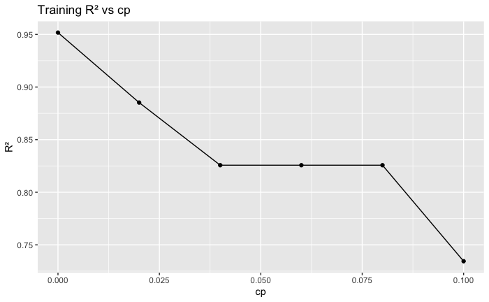

```r
# Plots how fit and complexity change with cp
ggplot(res, aes(cp, R2)) + geom_line() + geom_point() +
  labs(title = "Training R² vs cp", x = "cp", y = "R²")
```

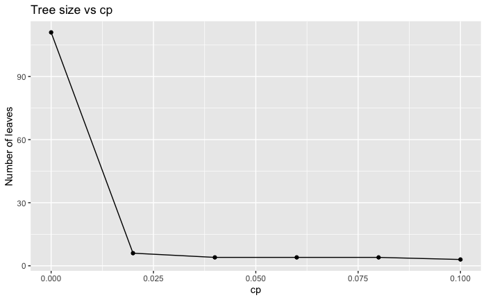

```r
ggplot(res, aes(cp, Leaves)) + geom_line() + geom_point() +
  labs(title = "Tree size vs cp", x = "cp", y = "Number of leaves")
```

```
## cp = 0


## cp = 0.02
```

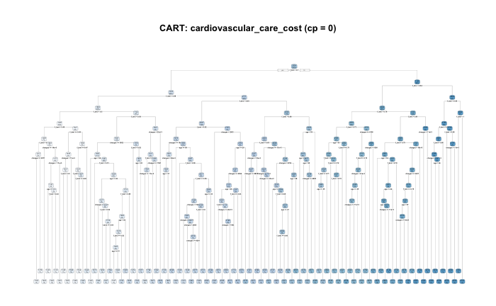

```
## cp = 0.04
```

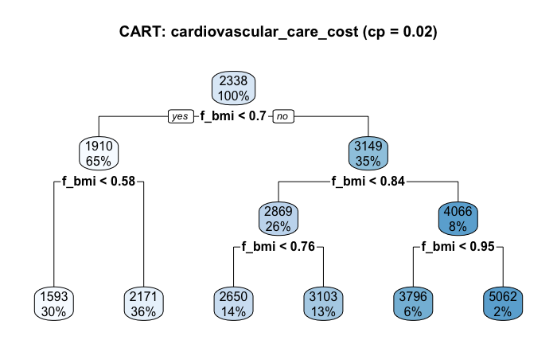

```
## cp = 0.06
```

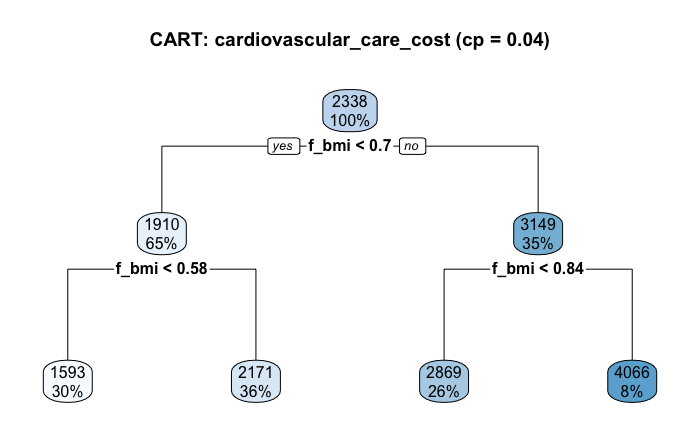

```
## cp = 0.08
```

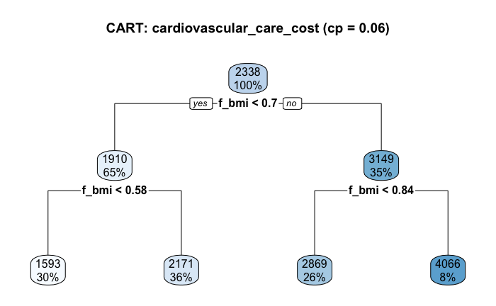

```
## cp = 0.1
```

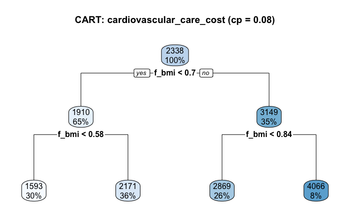

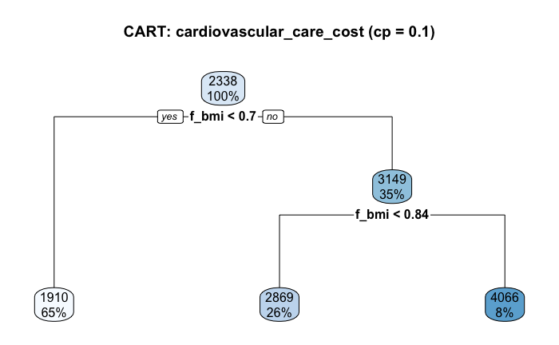

```r
# Plot each tree (one after another)
for (i in seq_len(nrow(res))) {
  cat("\n\n## cp =", res$cp[i], "\n")
  rpart.plot(res$model[[i]],
             main = paste0("CART: cardiovascular_care_cost (cp = ", res$cp[i], ")"))
}
```

When cp = 0, the tree grows very deep (12 levels, 111 leaves), leading to extremely high training R² (≈0.95) but clear overfitting, as seen in the highly complex structure. Increasing cp prunes the tree aggressively: at cp = 0.02, the tree shrinks to just 6 leaves and R² drops to ≈0.89. For cp = 0.04–0.08, the tree stabilizes with 4 leaves and depth 2, achieving R² around 0.83, which indicates a simpler but still reasonable fit. Finally, at cp = 0.10, the tree becomes even smaller (3 leaves, depth 2) and the R² falls further to ≈0.73, showing underfitting.

In summary, smaller cp values allow more complex trees with higher apparent training accuracy but risk overfitting, while larger cp values lead to simpler trees with reduced variance but higher bias. This trade-off highlights the importance of tuning cp to balance model complexity and predictive power, based on needs for expanability (e.g. Shallow tree is preferred as it can be visualized and human-parsed quickly) or performance, for instance.